# Gulf of Mexico well permits: a public US data file (Deckhand newsletter, issue 2)

**Review copy, revision 9 (removed at publication)**

Changes since revision 8: short figure and table titles with numbered notes below each; each pie set is one figure with one title, one legend and one set of notes, and only the year on each pie; a map of new wells as Figure 1; the day charts are interactive, one per stage in the order of a well's life; a slot for the shared Deckhand opening graphic; a hashtag line at the end.

The Deckhand newsletter · Issue 2 · Public data

# Gulf of Mexico well permits: a public US data file

> New-well permits in US federal waters of the Gulf of Mexico are far fewer each year than in the mid-2000s, and the permits have moved from jack-ups in shallow water to drillships in deep water. The public files of the US Bureau of Safety and Environmental Enforcement let your team check this and add its own questions, such as permit-day estimates by water depth.

## 1 Public permit data

Public data shows how new-well permits in US federal waters of the Gulf of America (formerly the Gulf of Mexico) have changed since 2005. The counts come from the Application for Permit to Drill (APD) raw data of the US Bureau of Safety and Environmental Enforcement (BSEE). The map and section 3 use its borehole and Application for Permit to Modify (APM) raw data.

Some of the observations are as follows:

- Of the 1,584 new wells started from 2005 to 2009, 68.8 % were in less than 100 m of water and 23.3 % in 500 m or more; of the 246 started from 2021 to 2025, 13.4 % and 82.5 % (Figure 1).
- Each year now has far fewer permits than in the mid-2000s (Figure 2).
- Most permits once named a jack-up rig; since 2015, most name a drillship (Figure 2).
- Permits in less than 100 m fell the most. Those in 500 m or more changed far less; since 2015, they are most permits (Figure 4).

Figure 1 shows where new wells started, coloured by water depth, in 2005 to 2009 and in 2021 to 2025. The buttons above the map switch between the two periods; the legend turns each water-depth band on or off.

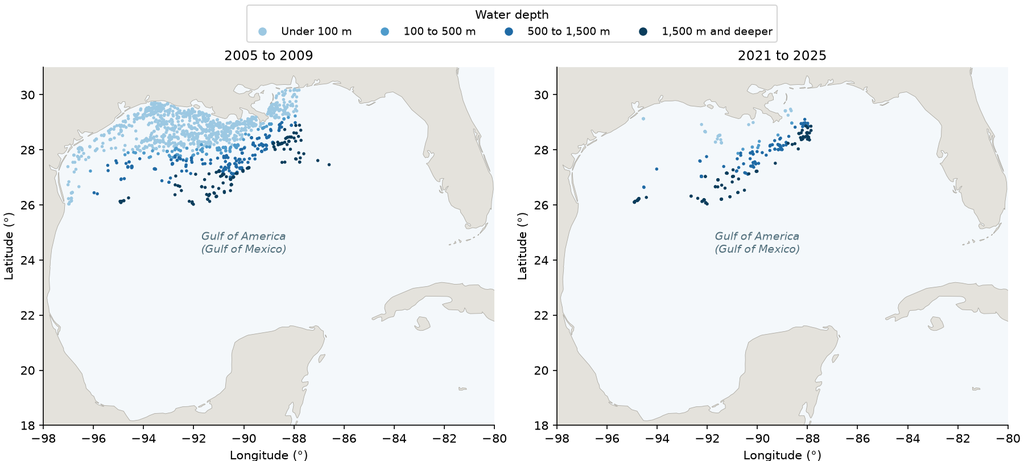

Figure 1 - Where new wells started, by water depth

1. Each dot is the surface location of an original borehole in the BSEE Gulf of Mexico region, spudded in 2005 to 2009 or in 2021 to 2025; cancelled boreholes are left out.

2. Counts: 2005 to 2009: 1,584 wells (under 100 m: 1,089; 100 to 500 m: 126; 500 to 1,500 m: 209; 1,500 m and deeper: 160); 2021 to 2025: 246 wells (under 100 m: 33; 100 to 500 m: 10; 500 to 1,500 m: 95; 1,500 m and deeper: 108). Wells without coordinates in the map area: 0.

3. Sources: BSEE borehole raw data (BoreholeRawData.zip), file of 12 November 2026, retrieved 13 November 2026; land outline from Natural Earth 1:50m land, version 5.1.2, public domain (ne_50m_land.geojson), retrieved 13 November 2026.

4. Data: map-wells.csv and map-summary.csv.

The [raw data page](https://www.data.bsee.gov/Main/RawData.aspx) of the BSEE Data Center lists the files used here, and files on platform structures, pipelines, production and offshore statistics by water depth.

## 2 Well permits by rig type and water depth

The permit file holds each application for a permit to drill in US federal waters. Each record gives:

- The permit type.
- The requested spud date: the date drilling is to start.
- The water depth.
- The rig name and rig type.

The counting rules are:

- Count each well once, at its first New Well permit in the Gulf of Mexico region.
- Use the requested spud year and the rig type named on that permit.

From 2005 to 2026, 2,895 wells are counted this way. The rule leaves out each well's later permits, and the 10 wells whose first New Well permit gives no requested spud date. The year 2026 runs only to the file of 2 November 2026.

### 2.1 Rig type

The counting script names six rig types:

- Jack-up.
- Drillship.
- Semisubmersible.
- DP semisubmersible: dynamically positioned, held on station by its thrusters.
- Platform rig.
- Submersible.

Barge, barge rig and well intervention vessel (19 permits) are grouped as other. Figure 2 shows the new-well permits each year by rig type. Figure 3 shows the shares in 2005, 2015 and 2025, one full year per decade.

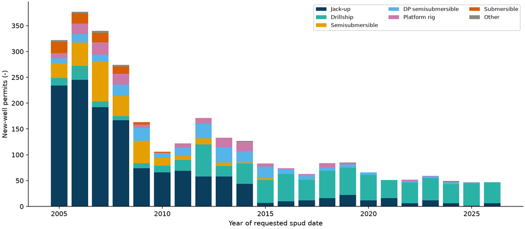

Figure 2 - New-well permits by rig type

1. Gulf of Mexico region, 2005 to 2026, by year of requested spud date; one permit per well.

2. Source: BSEE Application for Permit to Drill raw data (APDRawData.zip), file of 2 November 2026, retrieved 3 November 2026.

3. Data: fig-p1-new-well-permits-by-rig-type.csv.

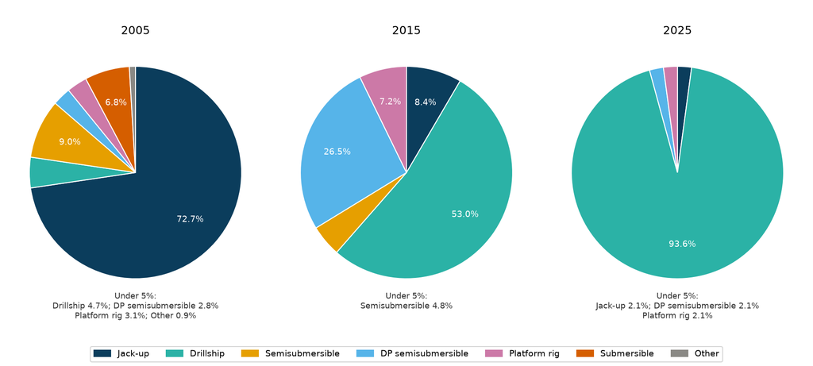

Figure 3 - Rig-type shares in 2005, 2015 and 2025

1. Permits each year: 322 in 2005, 83 in 2015, 47 in 2025.

2. A rig type with no permits in a year is left out of that year's pie.

3. Counts, source and file date as Figure 2. Data: pies-rig.csv.

### 2.2 Water depth

Every permit counted records a water depth. The file gives it in feet; this page gives it in metres (1 ft = 0.3048 m exactly, [NIST SP 811, Appendix B.8](https://www.nist.gov/pml/special-publication-811/nist-guide-si-appendix-b-conversion-factors/nist-guide-si-appendix-b8)). Figure 4 shows the new-well permits each year in four water-depth bands: under 100 m, 100 to 500 m, 500 to 1,500 m, and 1,500 m and deeper. A depth on a band edge is counted in the deeper band. Figure 5 shows the shares in the same three years.

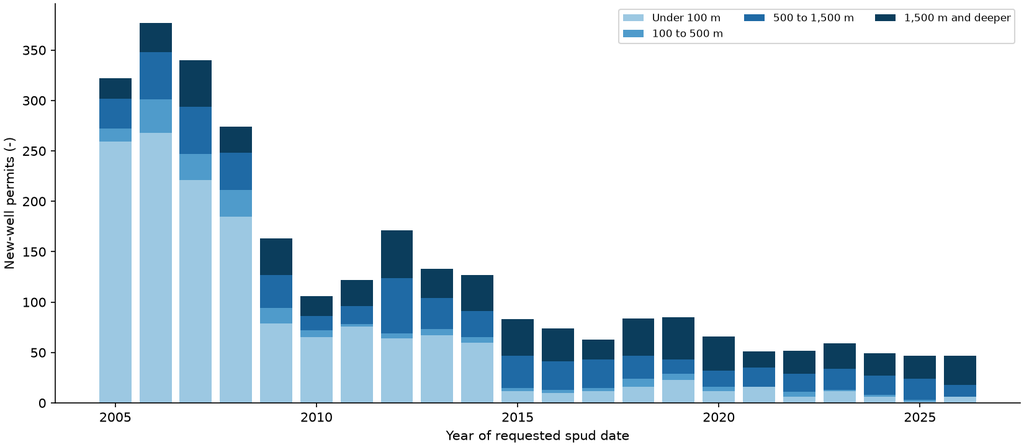

Figure 4 - New-well permits by water depth

1. Gulf of Mexico region, 2005 to 2026, by year of requested spud date; one permit per well.

2. Source: BSEE Application for Permit to Drill raw data (APDRawData.zip), file of 2 November 2026, retrieved 3 November 2026.

3. Data: new-well-permits-by-water-depth.csv.

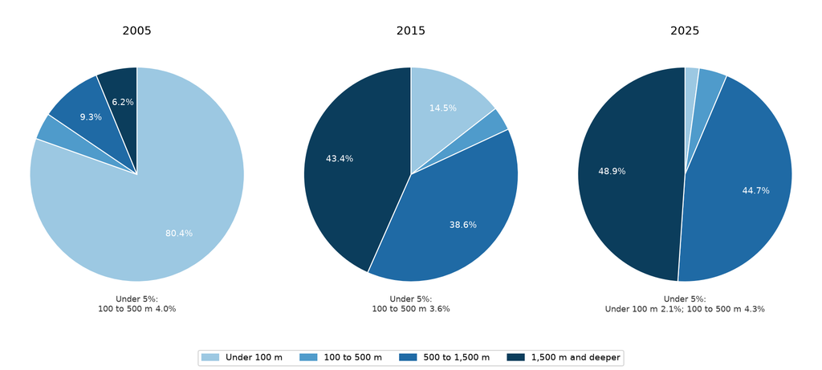

Figure 5 - Water-depth shares in 2005, 2015 and 2025

1. Permits each year: 322 in 2005, 83 in 2015, 47 in 2025.

2. A band with no permits in a year is left out of that year's pie.

3. Counts, source and file date as Figure 4. Data: pies-depth.csv.

### 2.3 Rig type and water depth

Table 1 gives the permits of each rig type in the same four bands, with each rig type's median water depth.

| Rig type | New-well permits, 2005 to 2026 (-) | Under 100 m (-) | 100 to 500 m (-) | 500 to 1,500 m (-) | 1,500 m and deeper (-) | Median water depth (m) |
| --- | --- | --- | --- | --- | --- | --- |
| Jack-up | 1,333 | 1,316 | 17 | 0 | 0 | 31 |
| Drillship | 758 | 0 | 5 | 323 | 430 | 1,581 |
| Semisubmersible | 282 | 0 | 51 | 151 | 80 | 985 |
| DP semisubmersible | 260 | 0 | 9 | 108 | 143 | 1,604 |
| Platform rig | 162 | 62 | 93 | 7 | 0 | 119 |
| Submersible | 81 | 81 | 0 | 0 | 0 | 12 |
| Other | 19 | 17 | 0 | 0 | 2 | 4 |
| All | 2,895 | 1,476 | 175 | 589 | 655 |  |

Table 1 - New-well permits by rig type and water depth

1. Gulf of Mexico region, 2005 to 2026; one permit per well.
2. Source: BSEE Application for Permit to Drill raw data (APDRawData.zip), file of 2 November 2026, retrieved 3 November 2026.
3. Data: table1.csv.

## 3 Days from drilling to abandonment

### 3.1 Observations

Some of the observations are as follows, in the order of a well's life:

- Drilling: recorded spud-to-total-depth medians rise with water depth, from 21 d under 100 m to 67 d at 1,500 m and deeper.
- Completion: estimate medians rise with water depth, from 10 d under 100 m to 40 d at 1,500 m and deeper.
- Intervention: estimate medians range from 7 to 22 d across the four depth bands.
- Temporary abandonment: estimate medians range from 5 to 14 d across the four depth bands.
- Permanent abandonment: estimate medians range from 7 to 20 d across the four depth bands.

### 3.2 Counting rules and exclusions

- Drilling days are the recorded dates from spud to total depth of each original borehole (borehole file).
- Days on completion, intervention and abandonment permits are the operator's estimate on each permit (APM file).
- Each original borehole or permit is counted once, for 2005 to 2025, in the same four water-depth bands.
- Missing, invalid, zero or negative days are left out and counted.
- The APD file holds no estimated drilling days.

The detailed rules and record counts are in Appendix B.

### 3.3 Days at each stage of a well's life

Figure 6 follows the life of a well: drilling, completion, intervention, temporary abandonment and permanent abandonment. Each chart gives the median and quartile days in the four water-depth bands; hover over a band for its values.

a. Drilling (recorded spud to total depth)

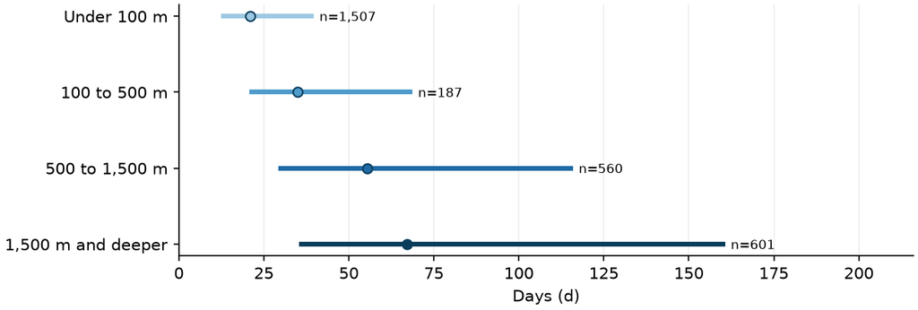

b. Completion (operator estimate)

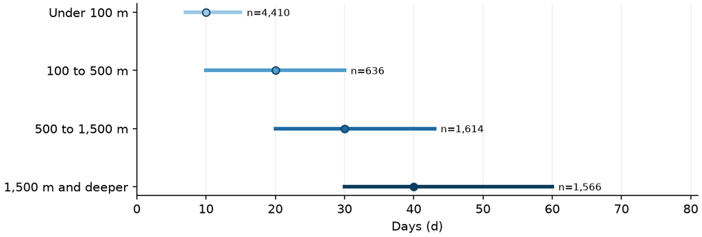

c. Intervention (operator estimate)

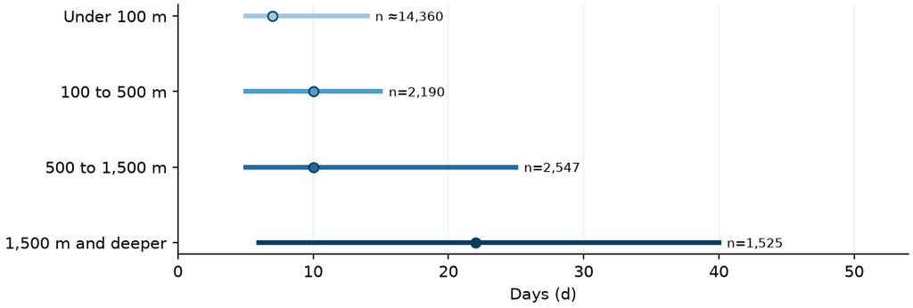

d. Temporary abandonment (operator estimate)

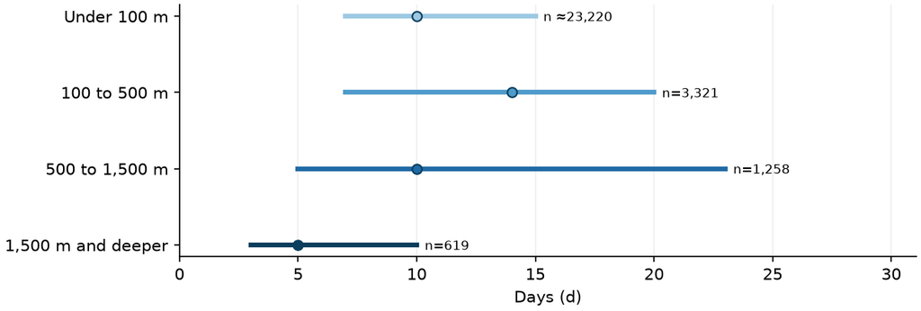

e. Permanent abandonment (operator estimate)

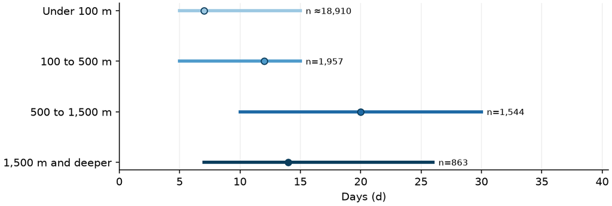

Figure 6 - Days at each stage of a well's life

1. By water-depth band. Dots are medians; bars run from the first to the third quartile. Labels give the count behind each median; ≈ marks rounding to four significant figures.

2. Drilling is the recorded calendar interval from spud to total depth of original boreholes spudded from 2005 to 2025. The other stages are operator estimates on permits to modify with status dates from 2005 to 2025.

3. Each chart has its own day scale.

4. Sources: BSEE BoreholeRawData.zip, file of 12 November 2026, retrieved 13 November 2026, and eWellAPMRawData.zip, file of 12 November 2026, retrieved 13 November 2026.

5. Data: days-summary.csv; full counts in Table B1.

## 4 Outlook and open points

### 4.1 Our hypotheses

Our hypothesis: with few new-well permits now naming a jack-up (Figure 2), jack-up work in US federal Gulf of Mexico waters will turn further from new wells to plugging and abandonment.

Our hypothesis: with deep-water permits falling far less than shallow-water permits (Figure 4), new-well engineering in these waters will centre further on deep-water drilling, risers and subsea equipment.

### 4.2 Open points

- Each count takes the rig type named in a well's first permit. How often a different type of rig drilled the well is open.
- Figure 6 shows recorded drilling intervals and operator estimates side by side; they come from different records and are not paired.
- The medians describe 2005 to 2025 as a whole.

### 4.3 Try it out

To try it out or adapt the analysis, see reusable prompt.

AceEngineer carries out fixed-scope engineering projects, and helps engineering firms build AI into everyday engineering work, including analysis of public offshore data such as this.

If you have run your own analysis, see a way to improve this one, or have an idea for a future issue, write to [the maintainers](https://www.aceengineer.com/). We read every reply and credit the ideas we use and provide results we obtained.

Approval: awaiting maintainer review of revision 9

#GulfOfAmerica #GulfOfMexico #OffshoreDrilling #Deepwater #PlugAndAbandonment #PublicData #BSEE #WellEngineering #DeckhandChronicles

## Appendix A Reusable prompts

This prompt lets your team recount new-well permits by rig type and water depth from the public BSEE permit file, map new wells by water depth, and read recorded drilling intervals and permit-day estimates by water depth from two further BSEE files. To have a study of your own public offshore data done for you instead, see below.

### What you need to run this

- Data required: the three BSEE files listed in the data-set line below, and the Natural Earth land outline for the map.
- Data required to adapt: the same files for another BSEE region, another range of years or other band edges.
- Paid or behind an account: none. The files download free without an account; Python, pandas and matplotlib are free.
- Changes over time: BSEE lists the files as updated daily, so a later download gives different counts; the file dates below fix the published values.

### Reproduce the published result

Give this prompt to your assistant:

Count each well once, at its first New Well permit in the Gulf of Mexico region, by requested spud year, rig type and water-depth band, from the Application for Permit to Drill file of 2 November 2026. The bands are under 100 m, 100 to 500 m, 500 to 1,500 m, and 1,500 m and deeper, from feet at 0.3048 m per foot, with a depth on an edge in the deeper band. Map the surface locations of original, not cancelled Gulf of Mexico boreholes spudded in 2005 to 2009 and in 2021 to 2025, by water-depth band, from the borehole file of 12 November 2026. Then compute medians and quartiles by band for 2005 to 2025, in the order of a well's life: recorded spud-to-total-depth days from the borehole file, then completion, intervention, temporary abandonment and permanent abandonment estimates from the Application for Permit to Modify file of 12 November 2026. Use the rules in Appendix B. Keep operator estimates apart from recorded intervals. Do not use cost data.

- Piece: Gulf of Mexico well permits: a public US data file, Deckhand newsletter issue 2, version of 13 November 2026.
- Code: build_r9.py at commit 6b2dbc38 of worldenergydata, which builds this page, in a draft pull request not yet merged. The counting script of the permit file is rawdata_fact_check at commit f5af5b6d, in an open pull request not yet merged.
- Software: Python 3.14.6, pandas 3.1.1 and matplotlib 3.11.2. Interactive charts load Plotly 2.35.2 from its release address with an integrity check; without it, each chart shows its static image. The permit counting script needs only the Python 3.10 or later standard library.
- Check values: 2,895 wells; band totals 1,476 (under 100 m), 175 (100 to 500 m), 589 (500 to 1,500 m) and 655 (1,500 m and deeper). Mapped wells: 1,584 (2005 to 2009) and 246 (2021 to 2025). Table B1 gives the quartiles and counts. Recorded spud-to-total-depth medians by band: 21, 35, 55.5, 67 d. Completion estimate medians by band: 10, 20, 30, 40 d.

### Adapt it to your project

Change the region code, the range of years, the band edges and the mapping of operation codes in the code mapping file. The checks that still apply: each well is counted once; the rig-type counts add up to the band totals; every exclusion is counted; duplicate APM records agree on every analysis field.

The public data set for this page is three files from the [BSEE Data Center raw data page](https://www.data.bsee.gov/Main/RawData.aspx) (US Department of the Interior). They are US federal government data, listed as updated daily. The map land outline is Natural Earth data, in the public domain.

- Application for Permit to Drill (APDRawData.zip), file of 2 November 2026, downloaded 3 November 2026, SHA-256 `b4ab66063de5a95c78d0e4d33d220ea806ef07f114bd2add6efa9e8561d299c0`: permit type, requested spud date, water depth, rig name and rig type.
- Application for Permit to Drill (APDRawData.zip), file of 12 November 2026, downloaded 13 November 2026, SHA-256 `8f5ce969356ab4fd1349a5218b238c161a348d62efca85c5296102341ed4ba21`: column check only: neither table holds an estimated-days field.
- Application for Permit to Modify (eWellAPMRawData.zip), file of 12 November 2026, downloaded 13 November 2026, SHA-256 `02b798158b5b9128637a04daa4b38dcb99aa349bd38a50211e8b9a85316f4629`: operation codes and sub-operations, estimated operation days, status date and water depth.
- Boreholes (BoreholeRawData.zip), file of 12 November 2026, downloaded 13 November 2026, SHA-256 `41d201b17c9982484fe781f797c1e621529e4d5469178d3c978843a316ae444e`: region, well-name suffix, spud and total-depth dates, status, water depth and surface location.
- Map land outline: Natural Earth 1:50m land (ne_50m_land.geojson, version 5.1.2, public domain), downloaded 13 November 2026, SHA-256 `e874b27a51d146452be360cafb3cc50c86001074a67d534113e6534682f9826b`.

To have a study of your own public offshore data done for you, write to [the maintainers](https://www.aceengineer.com/).

## Appendix B Counting rules and record counts for section 3

### B.1 Recorded intervals and estimates

- Borehole: `TOTAL_DEPTH_DATE` minus `WELL_SPUD_DATE` gives a recorded spud-to-total-depth calendar interval.
- APM: `EST_OPERATION_DAYS` is the operator's estimate on the permit.
- APD: in the permit file retrieved 13 November 2026, neither inspected APDRawData table has an estimated-days field. No drilling estimate is calculated from that file.

Figure 6 and Table B1 use full cohort years 2005 to 2025.

### B.2 Detailed counting rules and exclusions

- Borehole: count one `API_WELL_NUMBER` with `REGION_CODE=G`, original-hole suffix `ST00BP00` and status other than `CNL`. Select by spud year, 2005 to 2025. Use borehole `WATER_DEPTH`. The map uses the same boreholes, spudded in 2005 to 2009 or 2021 to 2025, at `SURF_LATITUDE` and `SURF_LONGITUDE`; the map selection counts give the wells without coordinates in the map area.
- Subtract dates without adding a day. A recorded total-depth date after 2025 remains in the spud-year cohort. Missing total-depth dates exclude unfinished or unreported intervals; results describe recorded completed intervals. Zero-day intervals may represent work within one day; they are excluded under the nonpositive-day rule. The audit separates zero, negative, blank-date and invalid-date cases.
- APM: count each `SN_APM` once. Duplicate rows must agree on API, status date, operation code, days and depth. Conflicts stop the build. Separate submissions for the same well remain separate observations; repeat API, operation and year keys are counted as a diagnostic below.
- Match the APM `API_WELL_NUMBER` exactly to an unambiguous borehole `REGION_CODE=G`. Exclude unmatched or conflicting regions. Use APM `WATER_DEPTH`.
- Select APM `ACC_STATUS_DATE` years 2005 to 2025. The file has no separate approval-status field; approved-only coverage is not established.
- Completion: `COMP` without `ZONE`. Intervention: `WORKOVER`, `ENHANCE`, or `COMP` with `ZONE`. This groups workover, production enhancement and recompletion. Completion does not mean initial completion only. ZONE takes precedence even when INITCOMP also occurs.
- Abandonment: `ABANDON` with `PERMABAN` or `TEMPABAN`. Permanent takes precedence if both occur. The estimate covers the whole submission, not an isolated subtype.
- Exclude any `PLUGBACK` subtype as new-hole work. Exclude unspecified abandonment and `OTHER`, `INFORM` and `UTIL`; their physical scope is unresolved. Unknown primary codes stop the build.
- The code mapping retains the source descriptions and analysis rules. Subtypes join through `SN_APM_FK`; they do not multiply observations. Classification uses codes, not free-text narratives. The subtype cross-tab shows the assigned activity. A submission can have several subtypes, so its rows are not additive.
- Convert feet to metres at 1 ft = 0.3048 m exactly (NIST SP 811, Appendix B.8). Use under 100 m, 100 to 500 m, 500 to 1,500 m, and 1,500 m and deeper. Band edges go to the deeper band.
- Exclude missing, invalid, infinite and nonpositive days from each median. Count those exclusions in Table B1 and days-summary.csv. Missing or invalid depth remains a separate row outside the four depth bands.
- Use linear interpolation for the 25th and 75th percentiles. Pool the full period without trimming large positive intervals. A missing median means no usable observations, not zero days.

No cost data is used.

The repeat-key sensitivity check also keeps only the latest status date per API, primary operation and status year. A date tie uses the last SN_APM in text order. It reports counts and medians beside the full-cohort values. 12 of 16 comparable cell medians change. The largest absolute change is 11 d. Shared keys do not prove revisions; distinct jobs can share them. This alternative does not replace the permit-based results.

**Selection counts before day exclusions**

- APM: raw records: ≈102,000 records.
- APM: duplicate rows: 207 records.
- APM: unmatched or ambiguous region: 0 records.
- APM: non gulf: 0 records.
- APM: missing status date: 0 records.
- APM: invalid nonblank status date: 0 records.
- APM: outside years: 3,901 records.
- APM: repeat api operation year extra submissions: ≈42,700 records.
- APM: Temporary abandonment: ≈28,520 records.
- APM: Permanent abandonment: ≈23,460 records.
- APM: Intervention: ≈20,720 records.
- APM: Excluded: other or administrative scope: ≈10,580 records.
- APM: Completion: 8,243 records.
- APM: Excluded: new hole: 4,804 records.
- APM: Excluded: unspecified abandonment: 1,606 records.
- APM: zero depth included: 0 records.
- Borehole: raw records: ≈57,520 records.
- Borehole: duplicate rows: 0 records.
- Borehole: non gulf: 1,933 records.
- Borehole: non original: ≈17,530 records.
- Borehole: cancelled: 762 records.
- Borehole: missing spud date: 17 records.
- Borehole: invalid nonblank spud date: 0 records.
- Borehole: outside years: ≈34,360 records.
- Borehole: zero depth selected: 0 records.
- Borehole: blank td selected: 34 records.
- Borehole: invalid nonblank td selected: 0 records.
- Borehole: zero interval selected: 24 records.
- Borehole: negative interval selected: 0 records.

Exact counts: exclusions.csv. Activity totals partition the selected APM records; other lines describe selection steps or named repeat-key and zero-depth diagnostics.

### B.3 Records and day exclusions by water depth

| Stage and basis | Water depth | Records (-) | Used (-) | Missing/invalid (-) | Nonpositive (-) | Q1 (d) | Median (d) | Q3 (d) |
| --- | --- | --- | --- | --- | --- | --- | --- | --- |
| Drilling (recorded spud to total depth) | Under 100 m | 1,515 | 1,507 | 1 | 7 | 13 | 21 | 39 |
| Drilling (recorded spud to total depth) | 100 to 500 m | 189 | 187 | 0 | 2 | 21.5 | 35 | 68 |
| Drilling (recorded spud to total depth) | 500 to 1,500 m | 585 | 560 | 16 | 9 | 30 | 55.5 | 115.2 |
| Drilling (recorded spud to total depth) | 1,500 m and deeper | 624 | 601 | 17 | 6 | 36 | 67 | 160 |
| Drilling (recorded spud to total depth) | Missing depth | 0 | 0 | 0 | 0 | Not available | Not available | Not available |
| Completion (operator estimate) | Under 100 m | 4,413 | 4,410 | 3 | 0 | 7 | 10 | 15 |
| Completion (operator estimate) | 100 to 500 m | 637 | 636 | 1 | 0 | 10 | 20 | 30 |
| Completion (operator estimate) | 500 to 1,500 m | 1,619 | 1,614 | 5 | 0 | 20 | 30 | 43 |
| Completion (operator estimate) | 1,500 m and deeper | 1,574 | 1,566 | 8 | 0 | 30 | 40 | 60 |
| Completion (operator estimate) | Missing depth | 0 | 0 | 0 | 0 | Not available | Not available | Not available |
| Intervention (operator estimate) | Under 100 m | ≈14,400 | ≈14,360 | 37 | 0 | 5 | 7 | 14 |
| Intervention (operator estimate) | 100 to 500 m | 2,198 | 2,190 | 8 | 0 | 5 | 10 | 15 |
| Intervention (operator estimate) | 500 to 1,500 m | 2,572 | 2,547 | 25 | 0 | 5 | 10 | 25 |
| Intervention (operator estimate) | 1,500 m and deeper | 1,552 | 1,525 | 27 | 0 | 6 | 22 | 40 |
| Intervention (operator estimate) | Missing depth | 0 | 0 | 0 | 0 | Not available | Not available | Not available |
| Temporary abandonment (operator estimate) | Under 100 m | ≈23,300 | ≈23,220 | 80 | 0 | 7 | 10 | 15 |
| Temporary abandonment (operator estimate) | 100 to 500 m | 3,326 | 3,321 | 5 | 0 | 7 | 14 | 20 |
| Temporary abandonment (operator estimate) | 500 to 1,500 m | 1,270 | 1,258 | 12 | 0 | 5 | 10 | 23 |
| Temporary abandonment (operator estimate) | 1,500 m and deeper | 624 | 619 | 5 | 0 | 3 | 5 | 10 |
| Temporary abandonment (operator estimate) | Missing depth | 0 | 0 | 0 | 0 | Not available | Not available | Not available |
| Permanent abandonment (operator estimate) | Under 100 m | ≈19,000 | ≈18,910 | 89 | 0 | 5 | 7 | 15 |
| Permanent abandonment (operator estimate) | 100 to 500 m | 1,964 | 1,957 | 7 | 0 | 5 | 12 | 15 |
| Permanent abandonment (operator estimate) | 500 to 1,500 m | 1,607 | 1,544 | 63 | 0 | 10 | 20 | 30 |
| Permanent abandonment (operator estimate) | 1,500 m and deeper | 893 | 863 | 30 | 0 | 7 | 14 | 26 |
| Permanent abandonment (operator estimate) | Missing depth | 0 | 0 | 0 | 0 | Not available | Not available | Not available |

Table B1 - Records, day exclusions and quartiles by stage and water depth

1. Stages in the order of a well's life, 2005 to 2025. Missing-depth rows are kept here, including zero counts.
2. Used is the count behind each median; missing or invalid days and nonpositive days are left out.
3. Displayed values use at most four significant figures; ≈ marks rounded counts.
4. Sources: BSEE BoreholeRawData.zip, file of 12 November 2026, retrieved 13 November 2026, and eWellAPMRawData.zip, file of 12 November 2026, retrieved 13 November 2026.
5. Data: days-summary.csv.

Questions: [Contact the maintainers](https://www.aceengineer.com/)

Deckhand: Make Engineering Enjoyable Again